```python
%reset -f
```

# (a solution to) THE KAGGLE CITY BIKE SHARE CHALLENGE

*Forecast use of a city bikeshare system*

*Bike sharing systems are a means of renting bicycles where the process of obtaining membership, rental, and bike return is automated via a network of kiosk locations throughout a city. Using these systems, people are able rent a bike from a one location and return it to a different place on an as-needed basis. Currently, there are over 500 bike-sharing programs around the world.*

*The data generated by these systems makes them attractive for researchers because the duration of travel, departure location, arrival location, and time elapsed is explicitly recorded. Bike sharing systems therefore function as a sensor network, which can be used for studying mobility in a city. In this competition, participants are asked to combine historical usage patterns with weather data in order to forecast bike rental demand in the Capital Bikeshare program in Washington, D.C.*

## We are given a training set with the following data:

- datetime: hourly date + timestamp by hour
  - yr : year (0: 2011, 1:2012)
  - mnth : month ( 1 to 12)
  - hr : hour (0 to 23)
- season:
  - 1 = winter (January-March)
  - 2 = spring (April-June)
  - 3 = summer (July-September)
  - 4 = fall (October-December)
- holiday: whether the day is considered a holiday
- workingday: if day is neither weekend nor holiday is 1, otherwise is 0.
- weather: encoded to make explicit various extreme weather events
  - 1 = Clear, Few clouds, Partly cloudy, Partly cloudy
  - 2 = Mist + Cloudy, Mist + Broken clouds, Mist + Few clouds, Mist
  - 3 = Light Snow, Light Rain + Thunderstorm + Scattered clouds, Light Rain + Scattered clouds)
  - 4 = Heavy Rain + Ice Pallets + Thunderstorm + Mist, Snow + Fog
- temp: Normalized temperature in Celsius. The values are divided to 41 (max)
- atemp: Normalized "feels like" temperature in Celsius. The values are divided to 50 (max)
- hum: Normalized humidity. The values are divided to 100 (max)
- windspeed: Normalized wind speed. The values are divided to 67 (max)
- casual: number of non-registered user rentals initiated
- registered: number of registered user rentals initiated
- count: count of total rental bikes including both casual and registered
- Two main rules:
  - "We ask that you respect the spirit of the competition and do not cheat. You should not submit entries based on test-set answers or train your model on the test set. Hand labeling is also forbidden."
  - "Your model should only use information which was available prior to the time for which it is forecasting."

```python
%reset -f
#Load all of settings, apis, etc.
%matplotlib inline

import pandas as pd
import seaborn as sns
import numpy as np
import matplotlib.pyplot as plt
from matplotlib import rcParams

from datetime import datetime, date, time, timedelta
from time import time, mktime, sleep
from calendar import monthrange
from math import log, sqrt

import os

rcParams['font.size'] = 10
rcParams['font.family'] = 'Helvetica'

pd.set_option('display.max_rows',40)
pd.set_option('display.max_columns',20)
pd.set_option('expand_frame_repr', True)
pd.set_option('display.mpl_style', 'default')
pd.set_option('max_colwidth',40)
```

```python
#Load the data
bike_train = pd.read_csv('/Users/rockyroxana/science/ga/bike_share/bike_share_repo/data/train.csv')#, index_col="datetime")
bike_test = pd.read_csv('/Users/rockyroxana/science/ga/bike_share/bike_share_repo/data/test.csv')#, index_col="datetime")
```

```python
#bike_train.tail(5)
#bike_test.head(5)
#bike_train.shape (10886,12)
#bike_test.shape (6493,9)
```

- Training set has 10,886 observations with 12 features, dating from January 1, 2011 through December 19, 2012.
- Test set has 6,493 observations and 9 of the 12 features, dating from January 20, 2011 to December 31, 2012. It *does not* include either the number of casual and registered rentals or the total count.
- Each month of the training set starts on the first of the month and ends on the 19th, and each month of the test set starts on the 20th and ends on the last day of that month.

```python
bike_train['hour'] = bike_train['datetime'].map(lambda x: (datetime.strptime(x, "%Y-%m-%d %H:%M:%S")).hour)
bike_train['weekday'] = bike_train['datetime'].map(lambda x: (datetime.strptime(x, "%Y-%m-%d %H:%M:%S")).isoweekday())
bike_train['month'] = bike_train['datetime'].map(lambda x: (datetime.strptime(x, "%Y-%m-%d %H:%M:%S")).month)
bike_train['year'] = bike_train['datetime'].map(lambda x: (datetime.strptime(x, "%Y-%m-%d %H:%M:%S")).year)
```

```python
bike_train.head()
```

|  | datetime | season | holiday | workingday | weather | temp | atemp | humidity | windspeed | casual | registered | count | hour | weekday | month | year |
| --- | --- | --- | --- | --- | --- | --- | --- | --- | --- | --- | --- | --- | --- | --- | --- | --- |
| 0 | 2011-01-01 00:00:00 | 1 | 0 | 0 | 1 | 9.84 | 14.39 | 81 | 0 | 3 | 13 | 16 | 0 | 6 | 1 | 2011 |
| 1 | 2011-01-01 01:00:00 | 1 | 0 | 0 | 1 | 9.02 | 13.63 | 80 | 0 | 8 | 32 | 40 | 1 | 6 | 1 | 2011 |
| 2 | 2011-01-01 02:00:00 | 1 | 0 | 0 | 1 | 9.02 | 13.63 | 80 | 0 | 5 | 27 | 32 | 2 | 6 | 1 | 2011 |
| 3 | 2011-01-01 03:00:00 | 1 | 0 | 0 | 1 | 9.84 | 14.39 | 75 | 0 | 3 | 10 | 13 | 3 | 6 | 1 | 2011 |
| 4 | 2011-01-01 04:00:00 | 1 | 0 | 0 | 1 | 9.84 | 14.39 | 75 | 0 | 0 | 1 | 1 | 4 | 6 | 1 | 2011 |

```python
bike_test['hour'] = bike_test['datetime'].map(lambda x: (datetime.strptime(x, "%Y-%m-%d %H:%M:%S")).hour)
bike_test['weekday'] = bike_test['datetime'].map(lambda x: (datetime.strptime(x, "%Y-%m-%d %H:%M:%S")).isoweekday())
bike_test['month'] = bike_test['datetime'].map(lambda x: (datetime.strptime(x, "%Y-%m-%d %H:%M:%S")).month)
bike_test['year'] = bike_test['datetime'].map(lambda x: (datetime.strptime(x, "%Y-%m-%d %H:%M:%S")).year)
```

```python
bike_train.columns
```

```
Index([u'datetime', u'season', u'holiday', u'workingday', u'weather', u'temp', u'atemp', u'humidity', u'windspeed', u'casual', u'registered', u'count', u'hour', u'weekday', u'month', u'year'], dtype='object')
```

Splitting the days by morning, afternoon, and evening may also be useful features.

- wee hours = 0:00 - 4:00
- early morning = 4:00 - 8:00
- morning 8:00 - 12:00
- afternoon 12:00 - 16:00
- evening 16:00 - 20:00
- late evening = 20:00-24:00

*Note: The datetime data only includes year-month-day-hour. It does not contain the data for the minutes between hours.*

```python
bike_train.insert(12,'dayPart', 0) #insert new column into df
bike_train.ix[(bike_train.hour>=0) & (bike_train.hour<4),'dayPart'] = 1 #wee hours
bike_train.ix[(bike_train.hour>=4) & (bike_train.hour<8),'dayPart'] = 2 #early morning
bike_train.ix[(bike_train.hour>=8) & (bike_train.hour<12),'dayPart'] = 3 #morning
bike_train.ix[(bike_train.hour>=12) & (bike_train.hour<16),'dayPart'] = 4 #afternoon
bike_train.ix[(bike_train.hour>=16) & (bike_train.hour<20),'dayPart'] = 5 #evening
bike_train.ix[(bike_train.hour>=20),'dayPart'] = 6 #late evening
```

```python
bike_test.insert(10,'dayPart', 0) #insert new column into df
bike_test.ix[(bike_test.hour>=0) & (bike_test.hour<4),'dayPart'] = 1 #wee hours
bike_test.ix[(bike_test.hour>=4) & (bike_test.hour<8),'dayPart'] = 2 #early morning
bike_test.ix[(bike_test.hour>=8) & (bike_test.hour<12),'dayPart'] = 3 #morning
bike_test.ix[(bike_test.hour>=12) & (bike_test.hour<16),'dayPart'] = 4 #afternoon
bike_test.ix[(bike_test.hour>=16) & (bike_test.hour<20),'dayPart'] = 5 #evening
bike_test.ix[(bike_test.hour>=20),'dayPart'] = 6 #late evening
```

We should also relabel the seasons, because January - March is most definitely not Spring.

```python
#Change the season values to numbers that make more sense
bike_train.ix[(bike_train.month >= 1) & (bike_train.month < 4),'season'] = 1 #Winter, Jan-Mar
bike_train.ix[(bike_train.month >= 4) & (bike_train.month < 7),'season'] = 2 #Spring, Apr-Jun
bike_train.ix[(bike_train.month >= 7) & (bike_train.month < 10),'season'] = 3 #Summer, Jul-Sept
bike_train.ix[(bike_train.month >= 10) & (bike_train.month < 13),'season'] = 4 #Summer, Oct-Dec

#Change the season values to numbers that make more sense
bike_test.ix[(bike_test.month >= 1) & (bike_test.month < 4),'season'] = 1 #Winter, Jan-Mar
bike_test.ix[(bike_test.month >= 4) & (bike_test.month < 7),'season'] = 2 #Spring, Apr-Jun
bike_test.ix[(bike_test.month >= 7) & (bike_test.month < 10),'season'] = 3 #Summer, Jul-Sept
bike_test.ix[(bike_test.month >= 10) & (bike_test.month < 13),'season'] = 4 #Summer, Oct-Dec
```

We want our all of our **categorical** variables be integers (i.e. *'season, 'holiday', 'workingday','weather', 'count', 'hour', 'dayPart', 'weekday', 'month', 'year'*) and all of our **numerical** variables to be floats (i.e. *'temp', 'atemp', 'humidity', and'windspeed'*). Looks like all we need to convert is **humidity**.

```python
bike_train['humidity'] = bike_train['humidity'].astype(float)
bike_test['humidity'] = bike_test['humidity'].astype(float)
```

```python
#bike_train.dtypes
#bike_test.dtypes
```

Now that I have all of the datetime information I need, we'll drop it from our dataframe...

```python
bike_train = bike_train.drop(['datetime'], axis = 1)
bike_test = bike_test.drop(['datetime'], axis = 1)
```

...and count the number of values for each attribute..

```python
#for attribute in bike_train.columns:
#    att_ct = [attribute, bike_train[attribute].value_counts()]
#    print ("\nAttribute: %s"% (att_ct[0]))
#    print ("Type: %s"% (bike_train[attribute].dtypes))
#    print ("Value Counts:\n%s\n"%(att_ct[1:]))
```

```python
bike_train.describe()
```

|  | season | holiday | workingday | weather | temp | atemp | humidity | windspeed | casual | registered | count | dayPart | hour | weekday | month | year |
| --- | --- | --- | --- | --- | --- | --- | --- | --- | --- | --- | --- | --- | --- | --- | --- | --- |
| count | 10886.00 | 10886.00 | 10886.00 | 10886.00 | 10886.00 | 10886.00 | 10886.00 | 10886.00 | 10886.00 | 10886.00 | 10886.00 | 10886.00 | 10886.00 | 10886.00 | 10886.00 | 10886.0 |
| mean | 2.51 | 0.03 | 0.68 | 1.42 | 20.23 | 23.66 | 61.89 | 12.80 | 36.02 | 155.55 | 191.57 | 3.51 | 11.54 | 4.01 | 6.52 | 2011.5 |
| std | 1.12 | 0.17 | 0.47 | 0.63 | 7.79 | 8.47 | 19.25 | 8.16 | 49.96 | 151.04 | 181.14 | 1.71 | 6.92 | 2.00 | 3.44 | 0.5 |
| min | 1.00 | 0.00 | 0.00 | 1.00 | 0.82 | 0.76 | 0.00 | 0.00 | 0.00 | 0.00 | 1.00 | 1.00 | 0.00 | 1.00 | 1.00 | 2011.0 |
| 25% | 2.00 | 0.00 | 0.00 | 1.00 | 13.94 | 16.66 | 47.00 | 7.00 | 4.00 | 36.00 | 42.00 | 2.00 | 6.00 | 2.00 | 4.00 | 2011.0 |
| 50% | 3.00 | 0.00 | 1.00 | 1.00 | 20.50 | 24.24 | 62.00 | 13.00 | 17.00 | 118.00 | 145.00 | 4.00 | 12.00 | 4.00 | 7.00 | 2012.0 |
| 75% | 4.00 | 0.00 | 1.00 | 2.00 | 26.24 | 31.06 | 77.00 | 17.00 | 49.00 | 222.00 | 284.00 | 5.00 | 18.00 | 6.00 | 10.00 | 2012.0 |
| max | 4.00 | 1.00 | 1.00 | 4.00 | 41.00 | 45.45 | 100.00 | 57.00 | 367.00 | 886.00 | 977.00 | 6.00 | 23.00 | 7.00 | 12.00 | 2012.0 |

```python
#Create some dictionaries for our graphs.
_seasons = {0:'Spring',1:'Summer',2:'Fall',3:'Winter'}

_months={0:'January', 1:'February',2:'March',
         3:'April', 4:'May',5:'June', 6:'July',
         7:'August',8: 'September', 9:'October',
         10:'November',11:'December'}

_days = {0:'Monday', 1:'Tuesday', 2:'Wednesday', 3:'Thursday',
         4:'Friday', 5:'Saturday', 6:'Sunday'}

_dayParts =["WeeHours\n(12am-4am)", "Early Morning\n(4am-8am)", "Morning\n(8am-12pm)",
            "Afternoon\n(12pm-4pm)", "Evening\n(4pm-8pm)", "Night\n(8pm-12am)"]

_weather = {0: "Clear",1: "Cloudy",2: "Rain", 3: "Yuck"}

_hours = {0:'12am',1:'1am',2:'2am',3:'3am',4:'4am',5:'5am',
            6:'6am',7:'7am',8:'8am',9:'9am',10:'10am',11:'11am',
           12:'12pm',13:'1pm',14:'2pm',15:'3pm',16:'4pm',17:'5pm',
            18:'6pm',19:'7pm',20:'8pm',21:'9pm',22:'10pm',23:'11pm'}
```

[figure not shown]

```python
sns.set(style= "white", context= "talk", font_scale=0.8)
sns.set_palette="Sequential"
sns.set_ylabel="Sequential"

fig = plt.figure(figsize=(16,20), dpi=1600)
fig.subplots_adjust(hspace = 0.5)
ax1 = plt.subplot2grid((4,2),(0,0))
plt.grid(b=True, which='major',axis ='y')
day_cts=bike_train.weekday.value_counts()
total_reg=bike_train['registered'].groupby(bike_train['weekday']).sum()
avg_reg_day=total_reg/day_cts
total_cas=bike_train['casual'].groupby(bike_train['weekday']).sum()
avg_cas_day=total_cas/day_cts
days=np.arange(len(day_cts))
sns.barplot(days, avg_reg_day, palette="Blues")
sns.barplot(days,avg_cas_day,palette="Greens", ax=ax1)
l = plt.legend(['Average Registered/day','Average Casual/day'], loc="best")
ax1.set_ylabel("Total Bikes")
sns.despine(left=True)
ax1.set_xlabel("Days")
ax1.set_xticklabels(_days)

ax2 = plt.subplot2grid((4,2),(2,0),colspan=2)
plt.grid(b=True, which='major',axis ='y' )
month_cts=bike_train.month.value_counts()
total_reg=bike_train['registered'].groupby(bike_train['month']).sum()
avg_reg_month=total_reg/month_cts
months=np.arange(len(month_cts))
total_cas=bike_train['casual'].groupby(bike_train['month']).sum()
avg_cas_month=total_cas/month_cts
sns.barplot(months, avg_reg_month, palette="BrBG")
ax2 = sns.barplot(months,avg_cas_month,palette="Reds",ax=ax2)
l = plt.legend(['Average Registered/month','Average Casual/month'], loc="best")
sns.despine(left=True)
ax2.set_ylabel("Total Bikes")
ax2.set_xlabel("Months")
ax2.set_xticklabels(_months)

ax3=plt.subplot2grid((4,2),(0,1))
plt.grid(b=True, which='major',axis ='y' )
season_cts=bike_train.season.value_counts()
total_reg=bike_train['registered'].groupby(bike_train['season']).sum()
avg_reg_season=total_reg/season_cts
seasons=np.arange(len(season_cts))
total_cas=bike_train['casual'].groupby(bike_train['season']).sum()
avg_cas_season=total_cas/season_cts
sns.barplot(seasons, avg_reg_season, palette="spring")
sns.barplot(seasons,avg_cas_season,palette="summer", ax=ax3)
l = plt.legend(['Average Registered/season','Average Casual/season'], loc="best")
sns.despine(left=True)
ax3.set_ylabel("Total Bikes")
ax3.set_xlabel("Seasons")
ax3.set_xticklabels(_seasons)

ax4=plt.subplot2grid((4,2),(1,0))
plt.grid(b=True, which='major',axis ='y' )
holiday_cts=bike_train.holiday.value_counts()
total_reg=bike_train['registered'].groupby(bike_train['holiday']).sum()
avg_reg_holiday=total_reg/holiday_cts
holidays=np.arange(len(holiday_cts))
total_cas=bike_train['casual'].groupby(bike_train['holiday']).sum()
avg_cas_holiday=total_cas/holiday_cts
sns.barplot(holidays, avg_reg_holiday, palette="RdPu")
sns.barplot(holidays,avg_cas_holiday,palette="PuRd", ax=ax4)
l = plt.legend(['Average Registered/holiday','Average Casual/holiday'], loc="best")
ax4.set_ylabel("Total Bikes")
ax4.set_xlabel("Holidays")
ax4.set_xticklabels(["Non-Holiday","Holiday"])

ax6=plt.subplot2grid((4,2),(1,1))
plt.grid(b=True, which='major',axis ='y' )
workday_cts=bike_train.workingday.value_counts()
total_reg=bike_train['registered'].groupby(bike_train['workingday']).sum()
avg_reg_workday=total_reg/workday_cts
workdays=np.arange(len(workday_cts))
total_cas=bike_train['casual'].groupby(bike_train['workingday']).sum()
avg_cas_workday=total_cas/workday_cts
sns.barplot(workdays, avg_reg_workday, palette="Blues")
sns.barplot(workdays,avg_cas_workday,palette="GnBu", ax=ax6)
l = plt.legend(['Average Registered/Workday','Average Casual/Workday'], loc="best")
sns.despine(left=True)
ax6.set_ylabel("Total Bikes")
ax6.set_xlabel("Workday")
ax6.set_xticklabels(["Weekend \nor Holiday","Workday"])

ax7=plt.subplot2grid((4,2),(3,0),colspan=2)
plt.grid(b=True, which='major',axis ='y' )
hour_cts=bike_train.hour.value_counts()
total_reg=bike_train['registered'].groupby(bike_train['hour']).sum()
avg_reg_hour=total_reg/hour_cts
hours=np.arange(len(hour_cts))
total_cas=bike_train['casual'].groupby(bike_train['hour']).sum()
avg_cas_hour=total_cas/hour_cts
sns.barplot(hours, avg_reg_hour, palette="pink")
sns.barplot(hours,avg_cas_hour,palette="gist_heat",ax=ax7)
l = plt.legend(['Average Registered/Hour', 'Average Casual/Hour'], loc="best")
sns.despine(left=True, bottom=True)
ax7.set_ylabel("Total Bikes")
ax7.set_xlabel("Hour")
ax7.set_xticklabels(_hours)

plt.show()
```

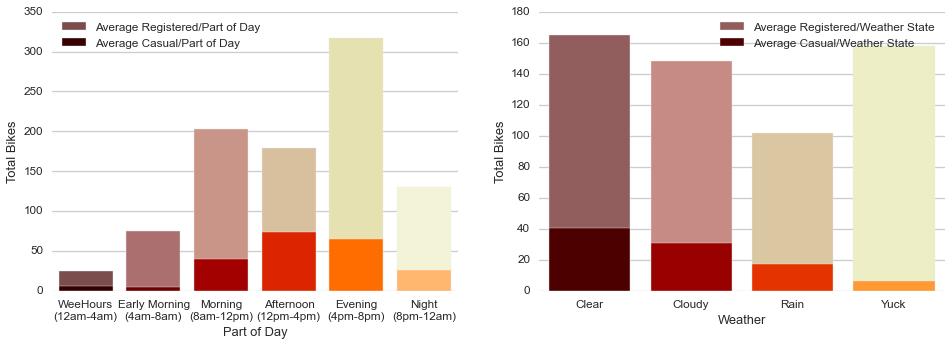

```python
sns.set(style= "white", context= "talk", font_scale=0.9)
sns.set_palette="Sequential"
sns.set_ylabel="Sequential"

fig = plt.figure(figsize=(16,5), dpi=1600)
fig.subplots_adjust(hspace = 0.5)

ax1 = plt.subplot2grid((1,2),(0,0))
plt.grid(b=True, which='major',axis ='y')
#sns.set(style= "white", context= "talk")
#f, ax = plt.subplots(figsize=(8, 6))
dayPart_cts=bike_train.dayPart.value_counts()
total_reg=bike_train['registered'].groupby(bike_train['dayPart']).sum()
avg_reg_dayPart=total_reg/dayPart_cts
dayParts=np.arange(len(dayPart_cts))
total_cas=bike_train['casual'].groupby(bike_train['dayPart']).sum()
avg_cas_dayPart=total_cas/dayPart_cts
sns.barplot(dayParts, avg_reg_dayPart, palette="pink")
sns.barplot(dayParts,avg_cas_dayPart,palette="gist_heat", ax=ax1)
l = plt.legend(['Average Registered/Part of Day','Average Casual/Part of Day'], loc="best")
ax1.set_ylabel("Total Bikes")
ax1.set_xlabel("Part of Day")
ax1.set_xticklabels(_dayParts)
sns.despine(left=True, bottom=True)

ax2 = plt.subplot2grid((1,2),(0,1))
plt.grid(b=True, which='major',axis ='y')
weather_cts=bike_train.weather.value_counts()
total_reg=bike_train['registered'].groupby(bike_train['weather']).sum()
avg_reg_weather=total_reg/weather_cts
total_cas=bike_train['casual'].groupby(bike_train['weather']).sum()
avg_cas_weather=total_cas/weather_cts
weathers=np.arange(len(weather_cts))
sns.barplot(weathers, avg_reg_weather, palette="pink")
sns.barplot(weathers,avg_cas_weather,palette="gist_heat", ax=ax2)
l = plt.legend(['Average Registered/Weather State','Average Casual/Weather State'], loc="best")
ax2.set_ylabel("Total Bikes")
sns.despine(left=True, bottom=True)
ax2.set_xlabel("Weather")
ax2.set_xticklabels(_weather)

plt.show()
```

[figure not shown]

```python
sns.set(style= "white", context= "talk")
sns.set_palette="Sequential"
fig = plt.figure(figsize=(16,10))

ax1 = plt.subplot2grid((4,2),(0,0),colspan=2)
plt.grid(b=True, which='major',axis ='y' )
atemp_cts=bike_train.atemp.value_counts()
total_reg=bike_train['registered'].groupby(bike_train['atemp']).sum()
avg_reg_atemp=total_reg/atemp_cts
atemps=np.arange(len(atemp_cts))
total_cas=bike_train['casual'].groupby(bike_train['atemp']).sum()
avg_cas_atemp=total_cas/atemp_cts
sns.barplot(atemps, avg_reg_atemp, palette="cool")
sns.barplot(atemps,avg_cas_atemp, palette="winter")
ax1 = sns.barplot(atemps,avg_cas_atemp,palette="Reds",ax=ax1)
l = plt.legend(['Average Registered/"feels like" temp','Average Casual/"feels like" temp'], loc="best")
sns.despine(left=True, bottom=True)
ax1.set_ylabel("Total Bikes")
ax1.set_xlabel("'Feels like' Temp (Celsius)")
_=plt.xticks([0, 15,30,45,max(atemps)], ["0","15","30","45","60"])

ax2=plt.subplot2grid((4,2),(1,0), colspan=2)
plt.grid(b=True, which='major',axis ='y' )
temp_cts=bike_train.temp.value_counts()
total_reg=bike_train['registered'].groupby(bike_train['temp']).sum()
avg_reg_temp=total_reg/temp_cts
temps=np.arange(len(temp_cts))
total_cas=bike_train['casual'].groupby(bike_train['temp']).sum()
avg_cas_temp=total_cas/temp_cts
sns.barplot(temps, avg_reg_temp, palette="cool")
sns.barplot(temps,avg_cas_temp,palette="winter", ax=ax2)
l = plt.legend(['Average Registered/temp','Average Casual/temp'], loc="best")
sns.despine(left=True, bottom=True)
ax2.set_ylabel("Total Bikes")
ax2.set_xlabel("Temperature (Celsius)")
sns.set(style= "white", context= "talk")
sns.set_palette="Sequential"
sns.set_ylabel="Sequential"

ax3=plt.subplot2grid((4,2),(2,0), colspan=2)
plt.grid(b=True, which='major',axis ='y' )
humid_cts=bike_train.humidity.value_counts()
total_reg=bike_train['registered'].groupby(bike_train['humidity']).sum()
avg_reg_humid=total_reg/humid_cts
humid=np.arange(len(humid_cts))
total_cas=bike_train['casual'].groupby(bike_train['humidity']).sum()
avg_cas_humid=total_cas/humid_cts
sns.barplot(humid, avg_reg_humid, palette="cool")
sns.barplot(humid,avg_cas_humid,palette="winter", ax=ax3)
l = plt.legend(['Average Registered/Humidity','Average Casual/Humidity'], loc="best")
sns.despine(left=True, bottom=True)
ax3.set_ylabel("Total Bikes")
_=plt.xticks([0, 20,40,60,80,max(humid)], ["0","20","40","60","80","100"])
ax3.set_xlim([0,len(humid)])

ax4=plt.subplot2grid((4,2),(3,0), colspan=2)
plt.grid(b=True, which='major',axis ='y' )
wind_cts=bike_train.windspeed.value_counts()
total_reg=bike_train['registered'].groupby(bike_train['windspeed']).sum()
avg_reg_wind=total_reg/wind_cts
winds=np.arange(len(wind_cts))
total_cas=bike_train['casual'].groupby(bike_train['windspeed']).sum()
avg_cas_wind=total_cas/wind_cts
sns.barplot(winds, avg_reg_wind, palette="cool", ax=ax4)
sns.barplot(winds,avg_cas_wind,palette="winter",ax=ax4)
l = plt.legend(['Average Registered/Windspeed','Average Casual/Windspeed'], loc="best")
sns.despine(left=True, bottom=True)
ax4.set_ylabel("Total Bikes")
ax4.set_xlabel("Windspeed")

plt.show()
```

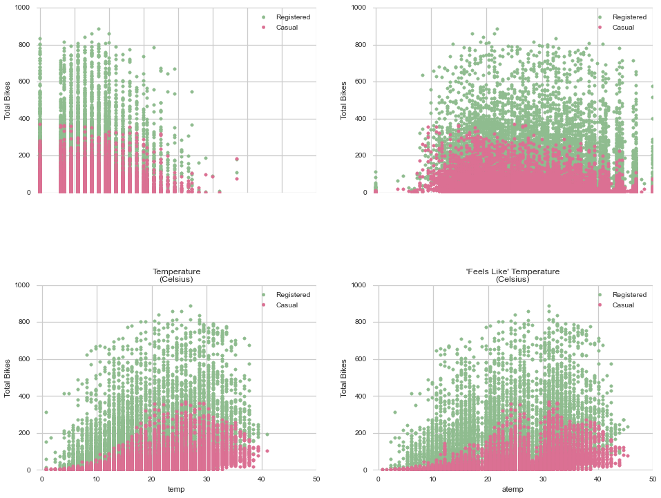

```python
sns.set(style= "white", context= "talk",font_scale=0.8)

fig = plt.figure(figsize=(16,12))

ax1 = plt.subplot2grid((2,2),(0,0))
plt.grid(b=True, which='major',axis ='y' )
bike_train.plot(kind='scatter',y='registered', x='windspeed',color='darkseagreen', label='Registered', ax=ax1)
bike_train.plot(kind='scatter', y='casual', x='windspeed', color='palevioletred',label='Casual',ax=ax1)
ax1.set_ylabel("Total Bikes")
ax1.set_ylim(-1,1000)
ax1.set_xlim(-1,80)

ax2 = plt.subplot2grid((2,2),(0,1))
plt.grid(b=True, which='major',axis ='y' )
bike_train.plot(kind='scatter',y='registered', x='humidity', color='darkseagreen', label='Registered', ax=ax2)
bike_train.plot(kind='scatter', y='casual', x='humidity',color='palevioletred',label='Casual', ax=ax2);
ax2.set_ylabel("Total Bikes")
ax2.set_ylim(-1,1000)
ax2.set_xlim(-1,100)
sns.despine(left=True, bottom=True)

ax3 = plt.subplot2grid((2,2),(1,0))
plt.grid(b=True, which='major',axis ='y' )
bike_train.plot(kind='scatter',y='registered', x='temp',color='darkseagreen', label='Registered', ax=ax3)
bike_train.plot(kind='scatter', y='casual', x='temp', color='palevioletred',label='Casual', ax=ax3);
ax3.set_ylabel("Total Bikes")
plt.title("Temperature\n(Celsius)")
ax3.set_xlim(-1,50)
ax3.set_ylim(-1,1000)

ax4 = plt.subplot2grid((2,2),(1,1))
plt.grid(b=True, which='major',axis ='y' )
bike_train.plot(kind='scatter',y='registered', x='atemp', color='darkseagreen',label='Registered', ax=ax4)
bike_train.plot(kind='scatter', y='casual', x='atemp',color='palevioletred', label='Casual', ax=ax4);
ax4.set_ylabel("Total Bikes")
plt.title("'Feels Like' Temperature\n(Celsius)");
ax4.set_xlim(-1,50)
ax4.set_ylim(-1,1000)

sns.despine(left=True, bottom=True)
plt.show()
```

Now the categorical variables will be transformed into a “dummy” or “indicator” matrix for each unique value of each category.

```python
season = pd.get_dummies(bike_train.iloc[:,0], prefix = 'd_season')
holiday = pd.get_dummies(bike_train.iloc[:,1], prefix = 'd_holiday')
workingday = pd.get_dummies(bike_train.iloc[:,2], prefix = 'd_workingday')
weather = pd.get_dummies(bike_train.iloc[:,3], prefix = 'd_weather')
dayPart = pd.get_dummies(bike_train.iloc[:,11], prefix = 'd_dayPart')
hour = pd.get_dummies(bike_train.iloc[:,12], prefix = 'd_hour')
weekday = pd.get_dummies(bike_train.iloc[:,13], prefix = 'd_weekday')
month = pd.get_dummies(bike_train.iloc[:,14], prefix = 'd_month')
year = pd.get_dummies(bike_train.iloc[:,15], prefix = 'd_year')
```

...and reconstruct our DataFrame for modeling.

```python
bike_train_final = bike_train.iloc[:,4:8]
#bike_train_final = bike_train_final.join(bike_train.iloc[:,:2]).join(bike_train.iloc[:,10:])
bike_train_final = bike_train_final.join(season)
bike_train_final = bike_train_final.join(holiday)
bike_train_final = bike_train_final.join(workingday)
bike_train_final = bike_train_final.join(weather)
bike_train_final = bike_train_final.join(dayPart)
bike_train_final = bike_train_final.join(hour)
bike_train_final = bike_train_final.join(weekday)
bike_train_final = bike_train_final.join(month)
bike_train_final = bike_train_final.join(year)
bike_train_final = bike_train_final.join(bike_train.iloc[:,8:11])
```

```python
#bike_train_final.dtypes
```

```python
#10886 - len(bike_train_final)/3
#bike_train_sample=bike_train_final.iloc[7259:,:]
#bike_train_final=bike_train_final[:7259]
```

I trained two seperate models, one for each of the 'casual' and 'registered' riders, and a composite model of the two is also trained for comparison purposes. Define total bike count and outcome variables for regressions and drop from training set.

```python
bike_count_y = bike_train_final['count']
bike_count_X = bike_train_final.drop('count', 1)
bike_count_X = bike_count_X.drop('registered', 1)
bike_count_X = bike_count_X.drop('casual', 1)

#casual
bike_casual_y = bike_train_final['casual']
bike_casual_X = bike_train_final.drop('casual',1)
bike_casual_X = bike_casual_X.drop('registered',1)
bike_casual_X = bike_casual_X.drop('count',1)

#registered
bike_reg_y = bike_train_final['registered']
bike_reg_X = bike_train_final.drop('registered',1)
bike_reg_X = bike_reg_X.drop('casual',1)
bike_reg_X = bike_reg_X.drop('count',1)

#entire DF without any count columns
trainingWheels = bike_train_final.drop(['casual','registered','count'], axis = 1)
```

```python
trainingWheels.shape
```

```
(10886, 67)
```

[figure not shown]

```python
from IPython.display import Image

Embed = Image('/Users/rockyroxana/Desktop/scikit_learn.png')
Embed
```

## LINEAR REGRESSION

As the rule states, "your model should only use information which was available prior to the time for which it is forecasting." I attempted to create 24 models but it was too computationally expensive.

```python
from sklearn.linear_model import LinearRegression
from sklearn.cross_validation import train_test_split

# Create cross validation sample
Xtrain, Xtest, ytrain_ct, ytest_ct, ytrain_cas, ytest_cas, ytrain_reg, ytest_reg = \
train_test_split(trainingWheels, bike_count_y, bike_casual_y, bike_reg_y, test_size = 0.33, random_state = 42)
```

```python
clf = LinearRegression()

casual_clf=clf.fit(Xtrain, ytrain_cas)
print "Train Casual R^2: {}".format(casual_clf.score(Xtrain, ytrain_cas))

registered_clf=clf.fit(Xtrain, ytrain_reg)
print "Train Registered R^2: {}".format(registered_clf.score(Xtrain, ytrain_reg))

count_clf=clf.fit(Xtrain, ytrain_ct)
print "Train Count R^2: {}".format(count_clf.score(Xtrain, ytrain_ct))
```

```
Train Casual R^2: 0.602013148014
Train Registered R^2: 0.699080077021
Train Count R^2: 0.701846293489
```

## EVALUATION

*Submissions are evaluated one the Root Mean Squared Logarithmic Error (RMSLE). The RMSLE is calculated as*

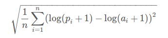

```python
from IPython.display import Image

Embed = Image('https://www.kaggle.com/blobs/download/forum-message-attachment-files/872/rmsle.png')
Embed
```

*Where:*

- *n* is the number of hours in the test set
- *pi* is your predicted count
- *a(i)* is the actual count
- *log(x)* is the natural logarithm

```python
from sklearn.metrics import make_scorer

#Some metric helpers
def rmsle(target, predicted):
    """Computes the root mean squared log error."""
    return np.sqrt(msle(target, predicted))


def msle(target, predicted):
    """Computes the mean squared log error."""
    return np.mean(sle(target, predicted))


def sle(target, predicted):
    """ Computes the squared log error."""
    return (np.power(np.log(np.array(target) + 1) -
            np.log(np.array(predicted) + 1), 2))


def rmse(target, predicted):
    ''' Computes the mean squared error'''
    return np.sqrt(np.mean((target-predicted)**2))

rmsle_scorer = make_scorer(rmsle, greater_is_better=False)
```

```python
casual_pred = casual_clf.predict(Xtest)
registered_pred = registered_clf.predict(Xtest)

# Compute prediction for total count as sum of casual and registered predictions
# Change any negative predictions to 0

casual_pred[casual_pred < 0] = 0
registered_pred[registered_pred < 0] = 0
count_pred = casual_pred + registered_pred

print "The Test Casual root mean squared log error is: {}".format(rmsle(casual_pred,ytest_cas))
print "The Test Registered root mean squared log error is: {}".format(rmsle(registered_pred,ytest_reg))
print "The Test Count root mean squared log error is: {}".format(rmsle(count_pred,ytest_ct))
```

```
The Test Casual root mean squared log error is: 2.29498349529
The Test Registered root mean squared log error is: 1.12233890954
The Test Count root mean squared log error is: 1.39463466096
```

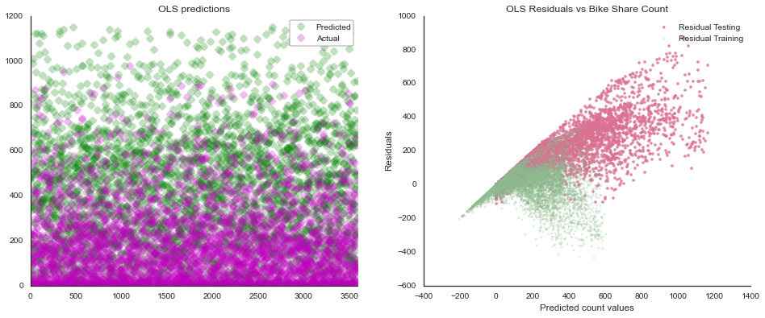

```python
# Plot Predictions Vs Actual
sns.set(style= "white", context= "talk",font_scale=0.8)

fig = plt.figure(figsize=(16,6))
ax1 = fig.add_subplot(121)
xindex = range(0, len(count_pred))
plt.plot(xindex, count_pred, 'go', xindex, ytest_ct, 'mo', alpha=.25);
plt.grid(color='white', linestyle='dashed')
plt.xlim(-1,len(count_pred))
l = plt.legend(['Predicted','Actual'], loc="best",frameon=True)
plt.title('OLS predictions')

ax2 = fig.add_subplot(122)
plt.scatter(count_pred, count_pred - ytest_ct, color='palevioletred', s=10, label='Residual Testing', alpha =0.8)
plt.scatter(count_clf.predict(Xtrain), count_clf.predict(Xtrain)- ytrain_ct, color='darkseagreen',
            s=5, alpha = 0.25, label='Residual Training')
plt.legend(loc="best")
plt.grid(color='white', linestyle='dashed')
plt.title('OLS Residuals vs Bike Share Count')
plt.xlabel("Predicted count values")
plt.ylabel("Residuals")
sns.despine()
plt.show()
```

## MODEL: RANDOM FOREST REGRESSOR

```python
bike_train.dtypes
```

```
season          int64
holiday         int64
workingday      int64
weather         int64
temp          float64
atemp         float64
humidity      float64
windspeed     float64
casual          int64
registered      int64
count           int64
dayPart         int64
hour            int64
weekday         int64
month           int64
year            int64
dtype: object
```

```python
bike_count_y = bike_train['count']
bike_count_X = bike_train.drop('count', 1)
bike_count_X = bike_count_X.drop('registered', 1)
bike_count_X = bike_count_X.drop('casual', 1)

#casual
bike_casual_y = bike_train['casual']
bike_casual_X = bike_train.drop('casual',1)
bike_casual_X = bike_casual_X.drop('registered',1)
bike_casual_X = bike_casual_X.drop('count',1)

#registered
bike_reg_y = bike_train['registered']
bike_reg_X = bike_train.drop('registered',1)
bike_reg_X = bike_reg_X.drop('casual',1)
bike_reg_X = bike_reg_X.drop('count',1)

#entire DF without any count columns
trainingWheels = bike_train.drop(['casual','registered','count'], axis = 1)
```

```python
# Create cross validation sample
Xtrain, Xtest, ytrain_ct, ytest_ct, ytrain_cas, ytest_cas, ytrain_reg, ytest_reg = \
train_test_split(trainingWheels, bike_count_y, bike_casual_y, bike_reg_y, test_size = 0.33, random_state = 42)
```

```python
from sklearn.ensemble import RandomForestRegressor

clf = RandomForestRegressor()

cas_rf=clf.fit(Xtrain, ytrain_cas)
print "Train Casual R^2: {}".format(cas_rf.score(Xtrain, ytrain_cas))

reg_rf=clf.fit(Xtrain,ytrain_reg)
print "Train Registered R^2: {}".format(reg_rf.score(Xtrain, ytrain_reg))

count_rf=clf.fit(Xtrain,ytrain_ct)
print "Train Count R^2: {}".format(count_rf.score(Xtrain, ytrain_ct))
```

```
Train Casual R^2: 0.980424483172
Train Registered R^2: 0.989922851257
Train Count R^2: 0.989019944149
```

```python
casual_pred_rf = cas_rf.predict(Xtest)
registered_pred_rf = reg_rf.predict(Xtest)

casual_pred_rf[casual_pred_rf < 0] = 0
registered_pred_rf[registered_pred_rf < 0] = 0
count_pred_rf = casual_pred_rf + registered_pred_rf

# Compute root RMSLE for each model on cv data
print "The Test Casual root mean squared log error is: {}".format(rmsle(casual_pred_rf,ytest_cas))
print "The Test Registered root mean squared log error is: {}".format(rmsle(registered_pred_rf,ytest_reg))
print "The Test Count root mean squared log error is: {}".format(rmsle(count_pred_rf,ytest_ct))
```

```
The Test Casual root mean squared log error is: 2.11896542459
The Test Registered root mean squared log error is: 0.449820547369
The Test Count root mean squared log error is: 0.827228192477
```

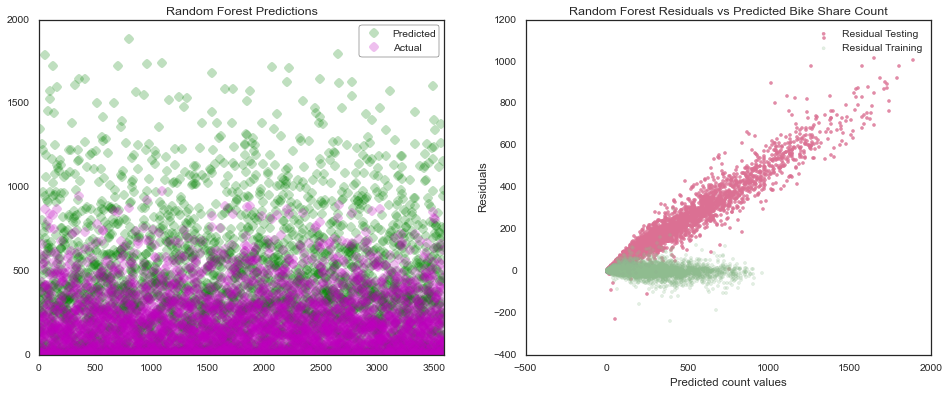

```python
# Plot Predictions Vs Actual
sns.set(style= "white", context= "talk",font_scale=0.8)

fig = plt.figure(figsize=(16,6))
ax1 = fig.add_subplot(121)
xindex = range(0, len(count_pred_rf))
plt.plot(xindex, count_pred_rf, 'go', xindex, ytest_ct, 'mo', alpha=.25);
plt.grid(color='white', linestyle='dashed')
plt.xlim(-1,len(count_pred_rf))
l = plt.legend(['Predicted','Actual'], loc="best",frameon=True)
plt.title('Random Forest Predictions')

ax2 = fig.add_subplot(122)
plt.scatter(count_pred_rf, count_pred_rf - ytest_ct, color='palevioletred', s=10, label='Residual Testing', alpha =0.8)
plt.scatter(count_rf.predict(Xtrain), count_rf.predict(Xtrain)- ytrain_ct, color='darkseagreen',
            s=10, alpha = 0.25, label='Residual Training')
plt.legend(loc="best")
plt.grid(color='white', linestyle='dashed')
plt.title('Random Forest Residuals vs Predicted Bike Share Count')
plt.xlabel("Predicted count values")
plt.ylabel("Residuals")
plt.show()
```

```python
from sklearn.grid_search import GridSearchCV

#Parameter Optimisation with grid search
tuned_parameters = [{'max_features': ['sqrt', 'log2', 'auto'], 'max_depth': [5, 8, 12],
                     'min_samples_leaf': [2, 5, 10]}]
rf =  GridSearchCV(RandomForestRegressor(n_jobs=1, n_estimators=1000), tuned_parameters, cv=3,
                   verbose=2, scoring=rmsle_scorer).fit(Xtrain, ytrain_ct)
```

[output not shown]

[output cut: 28 more lines]

[output not shown]

```
[Parallel(n_jobs=1)]: Done   1 jobs       | elapsed:    2.2s
[Parallel(n_jobs=1)]: Done  41 jobs       | elapsed:  2.2min
```

[output not shown]

[output cut: 25 more lines]

[output not shown]

```
[Parallel(n_jobs=1)]: Done  81 out of  81 | elapsed:  6.8min finished
```

```python
print 'Best Parameters:'
print rf.best_estimator_
```

```
Best Parameters:
RandomForestRegressor(bootstrap=True, compute_importances=None,
           criterion='mse', max_depth=12, max_features='auto',
           max_leaf_nodes=None, min_density=None, min_samples_leaf=2,
           min_samples_split=2, n_estimators=1000, n_jobs=1,
           oob_score=False, random_state=None, verbose=0)
```

```python
#Optimized model parameters

rf_op = RandomForestRegressor(bootstrap=True, compute_importances=None,
           criterion='mse', max_depth=12, max_features='auto',
           max_leaf_nodes=None, min_density=None, min_samples_leaf=2,
           min_samples_split=2, n_estimators=1000, n_jobs=1,
           oob_score=False, random_state=42, verbose=0)

rf_op.fit(Xtrain, ytrain_ct)
preds = rf_op.predict(Xtest)
```

```python
print "The Test Count root mean squared log error is: {}".format(rmsle(preds,ytest_ct))
```

```
The Test Count root mean squared log error is: 0.34392148674
```

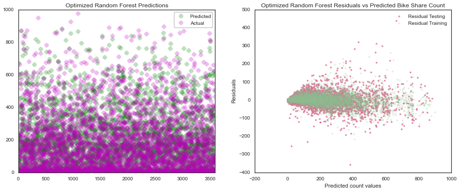

```python
# Plot Predictions Vs Actual
sns.set(style= "white", context= "talk",font_scale=0.8)

fig = plt.figure(figsize=(16,6))
ax1 = fig.add_subplot(121)
xindex = range(0, len(preds))
plt.plot(xindex, preds, 'go', xindex, ytest_ct, 'mo', alpha=.25);
plt.grid(color='white', linestyle='dashed')
plt.xlim(-1,len(preds))
l = plt.legend(['Predicted','Actual'], loc="best",frameon=True)
plt.title('Optimized Random Forest Predictions')

ax2 = fig.add_subplot(122)
plt.scatter(preds, preds - ytest_ct, color='palevioletred', s=10, label='Residual Testing', alpha =0.8)
plt.scatter(rf_op.predict(Xtrain), rf_op.predict(Xtrain)- ytrain_ct, color='darkseagreen',
            s=10, alpha = 0.25, label='Residual Training')
plt.legend(loc="best")
plt.grid(color='white', linestyle='dashed')
plt.title('Optimized Random Forest Residuals vs Predicted Bike Share Count')
plt.xlabel("Predicted count values")
plt.ylabel("Residuals")
plt.show()
```

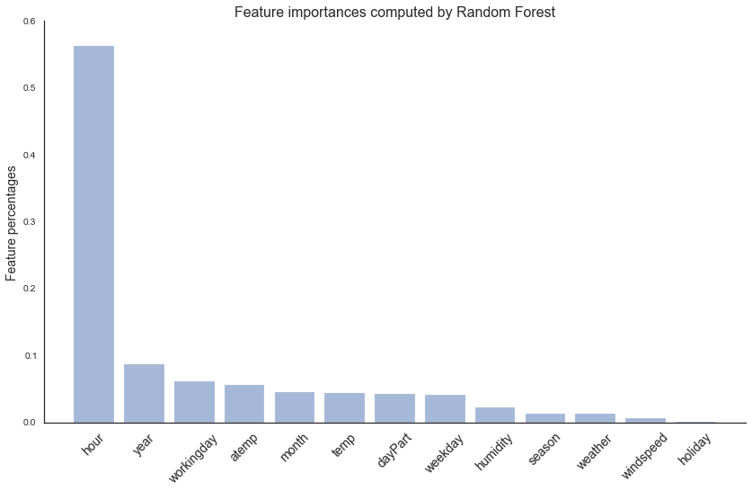

```python
features = trainingWheels.columns
numfeat = len(features)
plt.figure(figsize=(14,8))
indices = np.argsort(rf_op.feature_importances_)[::-1][:numfeat]
plt.bar(xrange(numfeat), rf_op.feature_importances_[indices], align='center', alpha=.5)
plt.xticks(xrange(numfeat), features[indices], rotation=45, fontsize=14)
plt.xlim([-1, numfeat])
plt.ylabel('Feature percentages', fontsize=14)
plt.title('Feature importances computed by Random Forest', fontsize=16)
sns.despine()
```

```python
num_feat = bike_train.iloc[:,4:8]
cat_feat = (bike_train.iloc[:,:3]).join(bike_train.iloc[:,12:])
```

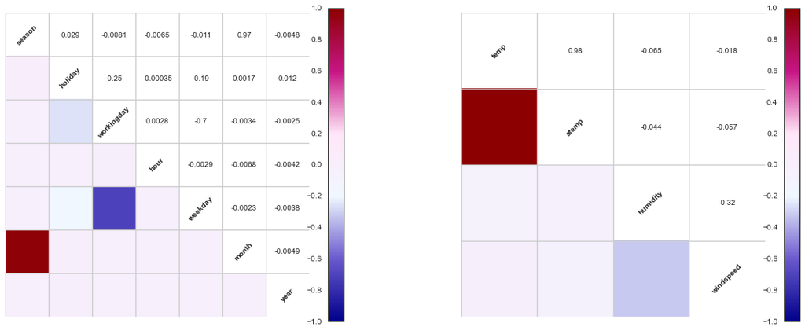

```python
sns.set(style= "white", context= "talk", font_scale=0.8)

cmap = sns.blend_palette(["#00008B", "#6A5ACD", "#F0F8FF",
                          "#FFE6F8", "#C71585", "#8B0000"], as_cmap=True)

fig = plt.figure(figsize=(20, 10))

ax1 = fig.add_subplot(121)
sns.corrplot(cat_feat, annot=True, ax=ax1, diag_names=True, cmap=cmap, method='pearson')
sns.despine(left='True', bottom='True')
ax1.grid(False)

ax2 = fig.add_subplot(122)
sns.corrplot(num_feat, ax=ax2, annot=True, diag_names=True, cmap=cmap, method='pearson')
sns.despine(left='True', bottom='True')
ax2.grid(False)
plt.show()
```

'atemp' is nearly correlated nearly 1:1 with 'temp' and provides more information to drop 'temp'. This will allow us to avoid multicollinearity in our model. Same with 'month' and 'season'; dropped 'season' as it is less specifc. 'weekday' and 'workday' are equally negatively correlated but 'workday' appears to be a more important feature. In contrast 'holiday' was deleted because it is already captured with 'workingday.

```python
trainingWheels.head()
#bike_count_X.head()
```

|  | season | holiday | workingday | weather | temp | atemp | humidity | windspeed | dayPart | hour | weekday | month | year |
| --- | --- | --- | --- | --- | --- | --- | --- | --- | --- | --- | --- | --- | --- |
| 0 | 1 | 0 | 0 | 1 | 9.84 | 14.39 | 81 | 0 | 1 | 0 | 6 | 1 | 2011 |
| 1 | 1 | 0 | 0 | 1 | 9.02 | 13.63 | 80 | 0 | 1 | 1 | 6 | 1 | 2011 |
| 2 | 1 | 0 | 0 | 1 | 9.02 | 13.63 | 80 | 0 | 1 | 2 | 6 | 1 | 2011 |
| 3 | 1 | 0 | 0 | 1 | 9.84 | 14.39 | 75 | 0 | 1 | 3 | 6 | 1 | 2011 |
| 4 | 1 | 0 | 0 | 1 | 9.84 | 14.39 | 75 | 0 | 2 | 4 | 6 | 1 | 2011 |

```python
bike_count_y = bike_train['count']
bike_count_X = bike_train.drop('count', 1)
bike_count_X = bike_count_X.drop('registered', 1)
bike_count_X = bike_count_X.drop('season', 1)
bike_count_X = bike_count_X.drop('temp', 1)
bike_count_X = bike_count_X.drop('weekday', 1)
bike_count_X = bike_count_X.drop('holiday',1)
bike_count_X = bike_count_X.drop('casual', 1)

#casual
bike_casual_y = bike_train['casual']
bike_casual_X = bike_train.drop('casual',1)
bike_casual_X = bike_casual_X.drop('registered', 1)
bike_casual_X = bike_casual_X.drop('season', 1)
bike_casual_X = bike_casual_X.drop('temp', 1)
bike_casual_X = bike_casual_X.drop('weekday', 1)
bike_casual_X = bike_casual_X.drop('holiday',1)
bike_casual_X = bike_casual_X.drop('count', 1)

#registered
bike_reg_y = bike_train['registered']
bike_reg_X = bike_train.drop('registered',1)
bike_reg_X = bike_reg_X.drop('casual',1)
#bike_reg_X = bike_reg_X.drop('season', 1)
#bike_reg_X = bike_reg_X.drop('temp', 1)
#bike_reg_X = bike_reg_X.drop('weekday', 1)
#bike_reg_X = bike_reg_X.drop('holiday',1)
bike_reg_X = bike_reg_X.drop('count',1)

#entire DF without any count columns
trainingWheels = bike_train.drop(['casual','registered','count', 'season', 'temp', 'weekday', 'holiday'], axis = 1)
```

## RIDGE REGRESSOR, RIDGECV

Ridge regression addresses some of the problems of Ordinary Least Squares by imposing a penalty on the size of coefficients. The ridge coefficients minimize a penalized residual sum of squares. alpha is a complexity parameter that controls the amount of shrinkage: the larger the value of alpha, the greater the amount of shrinkage and thus the coefficients become more robust to collinearity.

```python
from sklearn.linear_model import RidgeCV, Ridge

#Parameter Optimisation with RidgeCV

rdgCV = RidgeCV(alphas=[0.1, 1.0, 10.0], cv=None, fit_intercept=True, scoring=rmsle_scorer, normalize=False)

cas_rdg=rdgCV.fit(Xtrain, ytrain_cas)
print "Train Casual R^2: {}".format(cas_rdg.score(Xtrain, ytrain_cas))

reg_rdg=rdgCV.fit(Xtrain,ytrain_reg)
print "Train Registered R^2: {}".format(reg_rdg.score(Xtrain, ytrain_reg))

count_rdg=rdgCV.fit(Xtrain,ytrain_ct)
print "Train Count R^2: {}".format(count_rdg.score(Xtrain, ytrain_ct))
```

```
Train Casual R^2: 0.478266100471
Train Registered R^2: 0.345737675407
Train Count R^2: 0.399059031257
```

```python
casual_pred_rdg= cas_rdg.predict(Xtest)
registered_pred_rdg = reg_rdg.predict(Xtest)

# Compute prediction for total count as sum of casual and registered predictions
# Change any negative predictions to 0

casual_pred_rdg[casual_pred_rdg < 0] = 0
registered_pred_rdg[registered_pred_rdg < 0] = 0
count_pred_rdg = registered_pred_rdg + casual_pred_rdg

# Compute root RMSLE for each model on cv data
print "The Test Casual root mean squared log error is: {}".format(rmsle(casual_pred_rdg,ytest_cas))
print "The Test Registered root mean squared log error is: {}".format(rmsle(registered_pred_rdg,ytest_reg))
print "The Test Count root mean squared log error is: {}".format(rmsle(count_pred_rdg,ytest_ct))
```

```
The Test Casual root mean squared log error is: 2.51777680146
The Test Registered root mean squared log error is: 1.36013210042
The Test Count root mean squared log error is: 1.63986657597
```

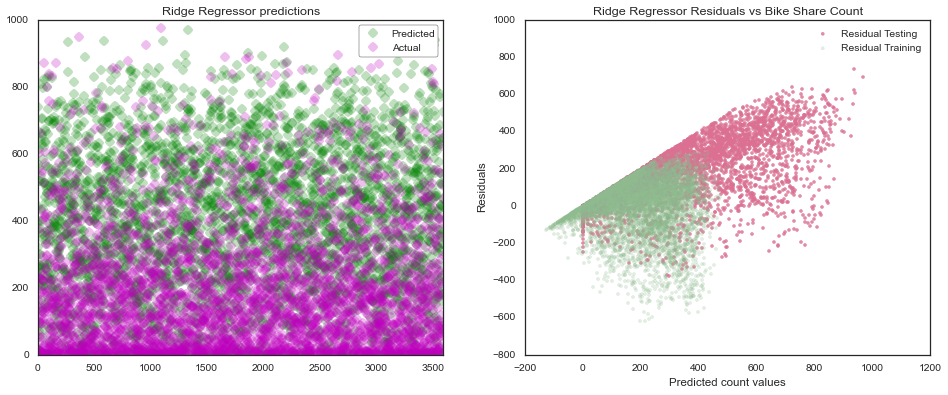

```python
# Plot Predictions Vs Actual
sns.set(style= "white", context= "talk",font_scale=0.8)

fig = plt.figure(figsize=(16,6))
ax1 = fig.add_subplot(121)
xindex = range(0, len(count_pred_rdg))
plt.plot(xindex, count_pred_rdg, 'go', xindex, ytest_ct, 'mo', alpha=.25);
plt.grid(color='white', linestyle='dashed')
plt.xlim(-1,len(count_pred_ridge))
l = plt.legend(['Predicted','Actual'], loc="best",frameon=True)
plt.title('Ridge Regressor predictions')

ax2 = fig.add_subplot(122)
plt.scatter(count_pred_rdg, count_pred_rdg - ytest_ct, color='palevioletred', s=10, label='Residual Testing',
            alpha =0.8)
plt.scatter(count_rdg.predict(Xtrain), count_rdg.predict(Xtrain)- ytrain_ct, color='darkseagreen',
            s=10, alpha = 0.25, label='Residual Training')
plt.legend(loc="best")
plt.grid(color='white', linestyle='dashed')
plt.title('Ridge Regressor Residuals vs Bike Share Count')
plt.xlabel("Predicted count values")
plt.ylabel("Residuals")
plt.show()
```

```python
rdgCV.alpha_
```

```
0.10000000000000001
```

```python
# Create cross validation sample
Xtrain, Xtest, ytrain_ct, ytest_ct, ytrain_cas, ytest_cas, ytrain_reg, ytest_reg = \
train_test_split(trainingWheels, bike_count_y, bike_casual_y, bike_reg_y, test_size = 0.33, random_state = 42)

clf = Ridge(alpha=rdgCV.alpha_)

cas_ridge=clf.fit(Xtrain, ytrain_cas)
print "Train Casual R^2: {}".format(cas_ridge.score(Xtrain, ytrain_cas))

reg_ridge=clf.fit(Xtrain,ytrain_reg)
print "Train Registered R^2: {}".format(reg_ridge.score(Xtrain, ytrain_reg))

count_ridge=clf.fit(Xtrain,ytrain_ct)
print "Train Count R^2: {}".format(count_ridge.score(Xtrain, ytrain_ct))
```

```
Train Casual R^2: 0.476129784473
Train Registered R^2: 0.345512497301
Train Count R^2: 0.398939079537
```

```python
casual_pred_ridge= cas_ridge.predict(Xtest)
registered_pred_ridge = reg_ridge.predict(Xtest)

# Compute prediction for total count as sum of casual and registered predictions
# Change any negative predictions to 0

casual_pred_ridge[casual_pred_ridge < 0] = 0
registered_pred_ridge[registered_pred_ridge < 0] = 0
count_pred_ridge = casual_pred_ridge + casual_pred_ridge

# Compute root RMSLE for each model on cv data
print "The Test Casual root mean squared log error is: {}".format(rmsle(casual_pred_ridge,ytest_cas))
print "The Test Registered root mean squared log error is: {}".format(rmsle(registered_pred_ridge,ytest_reg))
print "The Test Count root mean squared log error is: {}".format(rmsle(count_pred_ridge,ytest_ct))
```

```
The Test Casual root mean squared log error is: 2.51839381371
The Test Registered root mean squared log error is: 1.35941079555
The Test Count root mean squared log error is: 1.63886462218
```

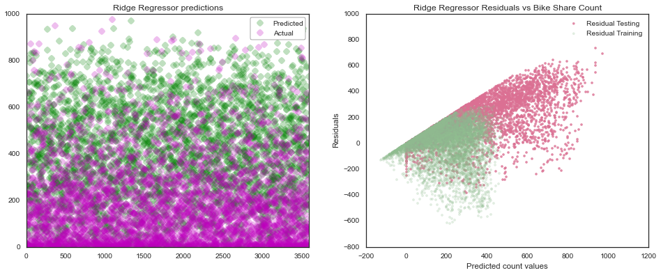

```python
# Plot Predictions Vs Actual
sns.set(style= "white", context= "talk",font_scale=0.8)

fig = plt.figure(figsize=(16,6))
ax1 = fig.add_subplot(121)
xindex = range(0, len(count_pred_ridge))
plt.plot(xindex, count_pred_ridge, 'go', xindex, ytest_ct, 'mo', alpha=.25);
plt.grid(color='white', linestyle='dashed')
plt.xlim(-1,len(count_pred_ridge))
l = plt.legend(['Predicted','Actual'], loc="best",frameon=True)
plt.title('Ridge Regressor predictions')

ax2 = fig.add_subplot(122)
plt.scatter(count_pred_ridge, count_pred_ridge - ytest_ct, color='palevioletred', s=10, label='Residual Testing',
            alpha =0.8)
plt.scatter(count_ridge.predict(Xtrain), count_ridge.predict(Xtrain)- ytrain_ct, color='darkseagreen',
            s=10, alpha = 0.25, label='Residual Training')
plt.legend(loc="best")
plt.grid(color='white', linestyle='dashed')
plt.title('Ridge Regressor Residuals vs Bike Share Count')
plt.xlabel("Predicted count values")
plt.ylabel("Residuals")
plt.show()
```